# Analyze A/B Test Results

```python
import pandas as pd
import numpy as np
import random
import matplotlib.pyplot as plt
%matplotlib inline
#We are setting the seed to assure you get the same answers on quizzes as we set up
random.seed(42)
```

**a.** Read in the dataset from the `ab_data.csv` file and take a look at the top few rows here:

```python
df=pd.read_csv('ab_data.csv')
df.head()
```

|  | user_id | timestamp | group | landing_page | converted |
| --- | --- | --- | --- | --- | --- |
| 0 | 851104 | 2017-01-21 22:11:48.556739 | control | old_page | 0 |
| 1 | 804228 | 2017-01-12 08:01:45.159739 | control | old_page | 0 |
| 2 | 661590 | 2017-01-11 16:55:06.154213 | treatment | new_page | 0 |
| 3 | 853541 | 2017-01-08 18:28:03.143765 | treatment | new_page | 0 |
| 4 | 864975 | 2017-01-21 01:52:26.210827 | control | old_page | 1 |

**b.** Use the cell below to find the number of rows in the dataset.

```python
df.shape
```

```
(294478, 5)
```

**c.** The number of unique users in the dataset.

```python
df['user_id'].nunique()
```

```
290584
```

**d.** The proportion of users converted.

```python
df.query('converted == 1').shape[0] / df.shape[0]
```

```
0.11965919355605512
```

**e.** The number of times when the "group" is `treatment` but "landing_page" is not a `new_page`.

```python
df.query("group == 'treatment' and landing_page != 'new_page'").shape[0]
```

```
1965
```

**f.** Do any of the rows have missing values?

```python
df.isna().sum()
```

```
user_id         0
timestamp       0
group           0
landing_page    0
converted       0
dtype: int64
```

**a.** Now use the answer to the quiz to create a new dataset that meets the specifications from the quiz. Store your new dataframe in **df2**.

```python
# Remove the inaccurate rows, and store the result in a new dataframe df2
drop_index = df.query("landing_page == 'new_page' and group == 'control'").index
drop_index2 = df.query("landing_page == 'old_page' and group == 'treatment'").index
total_dropindex = drop_index.append(drop_index2)
df2= df.drop(total_dropindex)
```

```python
# Double Check all of the incorrect rows were removed from df2 -
# Output of the statement below should be 0
df2[((df2['group'] == 'treatment') == (df2['landing_page'] == 'new_page')) == False].shape[0]
```

```
0
```

cleaning data

**a.** How many unique **user_id**s are in **df2**?

```python
df2.nunique()
```

```
user_id         290584
timestamp       290585
group                2
landing_page         2
converted            2
dtype: int64
```

**b.** There is one **user_id** repeated in **df2**. What is it?

```python
df2[df2.user_id.duplicated()].user_id
```

```
2893    773192
Name: user_id, dtype: int64
```

**c.** Display the rows for the duplicate **user_id**?

```python
df2[df2.user_id.duplicated()]
```

|  | user_id | timestamp | group | landing_page | converted |
| --- | --- | --- | --- | --- | --- |
| 2893 | 773192 | 2017-01-14 02:55:59.590927 | treatment | new_page | 0 |

**d.** Remove **one** of the rows with a duplicate **user_id**, from the **df2** dataframe.

```python
# Remove one of the rows with a duplicate user_id..
# Hint: The dataframe.drop_duplicates() may not work in this case because the rows with duplicate user_id are not entirely identical.
df2.drop(df2[df2.user_id.duplicated()].index, inplace=True)
# Check again if the row with a duplicate user_id is deleted or not
```

```python
df2.user_id.duplicated().sum()
```

```
0
```

**a.** What is the probability of an individual converting regardless of the page they receive?

```python
df2.query("converted == 1").shape[0] / df2.shape[0]
```

```
0.11959708724499628
```

**b.** Given that an individual was in the `control` group, what is the probability they converted?

```python
p_control = df2.query("converted == 1 and group == 'control'").shape[0]/df2.query("group == 'control'").shape[0]
print(p_control)
```

```
0.1203863045004612
```

**c.** Given that an individual was in the `treatment` group, what is the probability they converted?

```python
p_treatment= df2.query("converted == 1 and group == 'treatment'").shape[0]/df2.query("group == 'treatment'").shape[0]
print(p_treatment)
```

```
0.11880806551510564
```

```python
# Calculate the actual difference (obs_diff) between the conversion rates for the two groups.
```

[output not shown]

[output not shown]

**d.** What is the probability that an individual received the new page?

```python
df2.query('landing_page == "new_page"').shape[0]/df2.shape[0]
```

```
0.5000619442226688
```

**e.** Consider your results from parts (a) through (d) above, and explain below whether the new `treatment` group users lead to more conversions.

No, it does not seem as though one page leads to more conversions. The new page actually led to a lower conversion rate than the old page, but the difference appears to be negligible.

## Part II - A/B Test

1. For now, consider you need to make the decision just based on all the data provided. If you want to assume that the old page is better unless the new page proves to be definitely better at a Type I error rate of 5%, what should your null and alternative hypotheses be? You can state your hypothesis in terms of words or in terms of pold and pnew , which are the converted rates for the old and new pages.

H0 : H0: p_old >= p_new

H1 : P_new > P_old or...

H0 : Pold−Pnew >= 0

H1 : Pnew−Pold > 0

1. Assume under the null hypothesis, pnew and pold both have "true" success rates equal to the converted success rate regardless of page - that is pnew and pold are equal. Furthermore, assume they are equal to the converted rate in ab_data.csv regardless of the page.

**a.** What is the **conversion rate** for $p_{new}$ under the null hypothesis?

```python
p_null = df2['converted'].mean()
print(p_null)
```

```
0.119597087245
```

**b.** What is the **conversion rate** for $p_{old}$ under the null hypothesis?

```python
p_null
```

```
0.11959708724499628
```

**c.** What is $n_{new}$, the number of individuals in the treatment group?

```python
n_new = df2.query("landing_page == 'new_page'").shape[0]
print(n_new)
```

```
145310
```

**d.** What is $n_{old}$, the number of individuals in the control group?

```python
n_old = df2.query("landing_page == 'old_page'").shape[0]
print(n_old)
```

```
145274
```

**e. Simulate Sample for the `treatment` Group**  
Simulate $n_{new}$ transactions with a conversion rate of $p_{new}$ under the null hypothesis.

```python
# Simulate a Sample for the treatment Group
new_page_converted = np.random.binomial(1, p_null, n_new)
```

**f. Simulate Sample for the `control` Group**  
Simulate $n_{old}$ transactions with a conversion rate of $p_{old}$ under the null hypothesis.  
Store these $n_{old}$ 1's and 0's in the `old_page_converted` numpy array.

```python
# Simulate a Sample for the control Group
old_page_converted = np.random.binomial(1, p_null, n_old)
```

**g.** Find the difference in the "converted" probability $(p{'}_{new}$ - $p{'}_{old})$ for your simulated samples from the parts (e) and (f) above.

```python
new_page_converted.mean() - old_page_converted.mean()
```

```
-0.00091741021536927148
```

**h. Sampling distribution**  
Re-create `new_page_converted` and `old_page_converted` and find the $(p{'}_{new}$ - $p{'}_{old})$ value 10,000 times using the same simulation process you used in parts (a) through (g) above.

Store all $(p{'}_{new}$ - $p{'}_{old})$ values in a NumPy array called `p_diffs`.

```python
# Sampling distribution
p_diffs = []
new_converted_simulation = np.random.binomial(n_new, p_null, 10000)/n_new
old_converted_simulation = np.random.binomial(n_old, p_null, 10000)/n_old
p_diffs = new_converted_simulation - old_converted_simulation
```

**i. Histogram**  
Plot a histogram of the **p_diffs**. Does this plot look like what you expected? Use the matching problem in the classroom to assure you fully understand what was computed here.

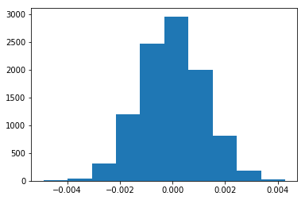

```python
plt.hist(p_diffs);
```

**j.** What proportion of the **p_diffs** are greater than the actual difference observed in the `df2` data?

```
0.9027
```

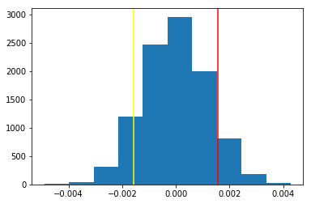

```python
a =(p_diffs > obs_diff).mean()

plt.hist(p_diffs);
plt.axvline(obs_diff, color='yellow');
plt.axvline(p_diffs.mean() + (p_diffs.mean() - obs_diff), color='red');
print(a)
```

In words, explain what you just computed in part j.. What is this value called in scientific studies? What does this value mean in terms of whether or not there is a difference between the new and old pages?

l. We could also use a built-in to achieve similar results. Though using the built-in might be easier to code, the above portions are a walkthrough of the ideas that are critical to correctly thinking about statistical significance. Fill in the below to calculate the number of conversions for each page, as well as the number of individuals who received each page. Let n_old and n_new refer the the number of rows associated with the old page and new pages, respectively.

```python
import statsmodels.api as sm

# number of conversions with the old_page
convert_old = df2.query('group == "control" & converted == 1')['converted'].sum()


# number of conversions with the new_page
convert_new =df2.query('group == "treatment" & converted == 1')['converted'].sum()


n_old , n_new ,convert_old , convert_new
```

```
(145274, 145310, 17489, 17264)
```

**m.** Now use `sm.stats.proportions_ztest()` to compute your test statistic and p-value. [Here](https://www.statsmodels.org/stable/generated/statsmodels.stats.proportion.proportions_ztest.html) is a helpful link on using the built in.

The syntax is:

```
proportions_ztest(count_array, nobs_array, alternative='larger')
```

where,

- `count_array` = represents the number of "converted" for each group
- `nobs_array` = represents the total number of observations (rows) in each group
- `alternative` = choose one of the values from `[‘two-sided’, ‘smaller’, ‘larger’]` depending upon two-tailed, left-tailed, or right-tailed respectively.

  > **Hint**:  
  > It's a two-tailed if you defined $H_1$ as $(p_{new} = p_{old})$.  
  > It's a left-tailed if you defined $H_1$ as $(p_{new} < p_{old})$.  
  > It's a right-tailed if you defined $H_1$ as $(p_{new} > p_{old})$.

The built-in function above will return the z_score, p_value.